# Introducción a los Promedios Estadísticos

Autor/a

Fred Torres Cruz

Fecha de publicación

1 de abril de 2025

# 1 Introducción a los Promedios

Los promedios son medidas de tendencia central que nos permiten resumir información sobre un conjunto de datos. Estas medidas son fundamentales en estadística descriptiva y nos ayudan a comprender la distribución de los datos.

## 1.1 ¿Por qué son importantes?

Las medidas de tendencia central nos permiten:

- Resumir grandes conjuntos de datos
- Comparar diferentes conjuntos de datos
- Tomar decisiones basadas en valores representativos
- Identificar patrones y tendencias

# 2 Tipos de Promedios

Existen diferentes tipos de promedios, cada uno con sus propias características y aplicaciones.

## 2.1 Media Aritmética

La media aritmética es el promedio más común. Se calcula sumando todos los valores y dividiendo por el número total de observaciones.

$$\bar{x} = \frac{\sum_{i=1}^{n} x_i}{n}$$

**Código**

```r
datos <- c(4, 8, 15, 16, 23, 42)
media <- mean(datos)
cat("Media aritmética:", media)
```

```
Media aritmética: 18
```

## 2.2 Mediana

La mediana es el valor que divide el conjunto de datos en dos partes iguales. Es menos sensible a valores extremos que la media aritmética.

**Código**

```r
mediana <- median(datos)
cat("Mediana:", mediana)
```

```
Mediana: 15.5
```

## 2.3 Moda

La moda es el valor que aparece con mayor frecuencia en un conjunto de datos. Un conjunto puede tener más de una moda.

**Código**

```r
datos_con_moda <- c(2, 3, 3, 4, 5, 5, 5, 6, 7)
# Función para calcular la moda
calcular_moda <- function(x) {
  tabla <- table(x)
  as.numeric(names(tabla)[tabla == max(tabla)])
}
cat("Moda:", calcular_moda(datos_con_moda))
```

```
Moda: 5
```

# 3 Comparación de Medidas

Cada medida de tendencia central tiene sus ventajas y desventajas:

| Medida | Ventajas | Desventajas |
| --- | --- | --- |
| Media | Utiliza todos los valores | Sensible a valores extremos |
| Mediana | Resistente a valores extremos | No considera todos los valores |
| Moda | Útil para datos categóricos | Puede no ser única |

# 4 Ejemplo Práctico

Veamos un ejemplo práctico de cómo estas medidas pueden variar:

**Código**

```r
# Conjunto de datos normal
datos_normal <- c(10, 12, 13, 14, 15, 16, 18)

# Conjunto con valor extremo
datos_extremo <- c(10, 12, 13, 14, 15, 16, 100)

# Comparación
comparacion <- data.frame(
  Conjunto = c("Normal", "Con valor extremo"),
  Media = c(mean(datos_normal), mean(datos_extremo)),
  Mediana = c(median(datos_normal), median(datos_extremo))
)

# Mostrar tabla
library(knitr)
kable(comparacion)
```

| Conjunto | Media | Mediana |
| --- | --- | --- |
| Normal | 14.00000 | 14 |
| Con valor extremo | 25.71429 | 14 |

Comparación de medidas de tendencia central

**Código**

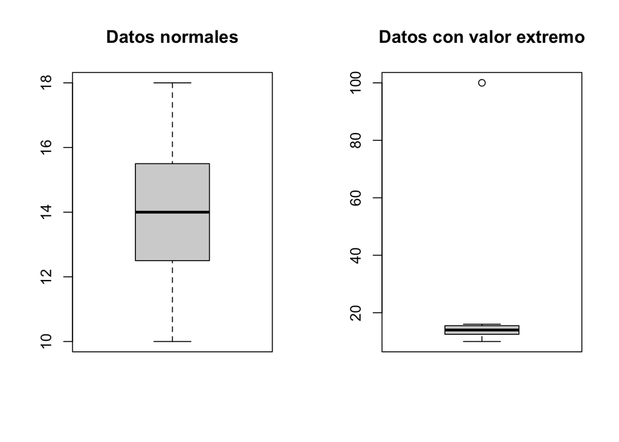

Comparación de medidas de tendencia central

```r
# Visualización
par(mfrow=c(1,2))
boxplot(datos_normal, main="Datos normales")
boxplot(datos_extremo, main="Datos con valor extremo")
```

# 5 Conclusiones

- La elección del promedio adecuado depende del tipo de datos y del objetivo del análisis.
- Es recomendable calcular varias medidas de tendencia central para obtener una imagen más completa de los datos.
- Los promedios deben complementarse con medidas de dispersión para una interpretación adecuada.

# 6 Referencias

1. Pérez, J. (2023). *Estadística Descriptiva: Un enfoque práctico*. Editorial Académica.
2. López, M. (2024). *Análisis de Datos con R*. Universidad Nacional.
3. Martínez, R. (2022). *Introducción a la Estadística*. Editorial Científica.